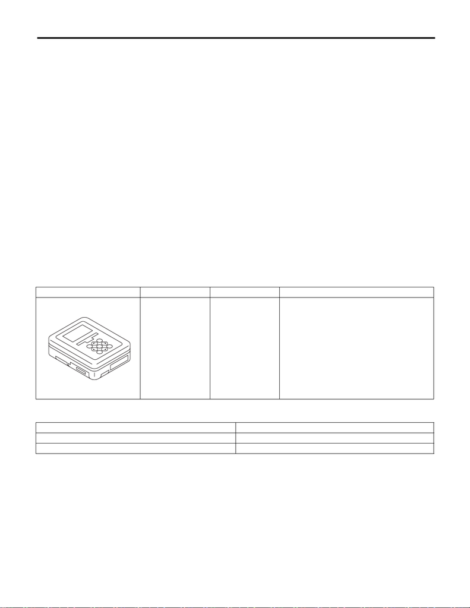

General Description

MANUAL TRANSMISSION AND DIFFERENTIAL (DIAGNOSTICS)

3. General Description

A: CAUTION

The airbag system wiring harness is routed near the DCCD control module.

CAUTION:

• Airbag system wiring harnesses and connectors are yellow. Do not use an electric test equipment

to check these circuits.

• Be careful not to damage the airbag system wiring harness when performing diagnostics or repair

of the DCCD control module.

• When measuring the voltage and resistance of each control module or each sensor, use a tapered

pin with a diameter of less than 0.64 mm (0.025 in) in order to avoid poor contact. Also, do not insert

the pin more than 5 mm (0.2 in) into the part.

B: INSPECTION

1. POWER SUPPLY

1) Measure the battery voltage and specific gravity of the electrolyte.

Standard voltage: 12 V or more

Specific gravity: 1.260 or more

2) Check the fuse condition.

3) Check the connecting condition of harness and harness connector.

C: PREPARATION TOOL

1. SPECIAL TOOL

2. GENERAL TOOL

ILLUSTRATION TOOL NUMBER DESCRIPTION REMARKS

1B022XU0 SUBARU SELECT

MONITOR III KIT

Troubleshooting for electrical system

TOOL NAME REMARKS

Circuit tester Used for measuring resistance, voltage and current.

Oscilloscope Used for measuring the sensor.